# **Cookbook**

My Subtitle because subtitles are great and long and great and commonly span multiple lines arent they great? arent yours not? I can’t believe how long they can be

Márton Kiss

$~$  
$~$  
$~$  
$~$

I affirm that all results presented withtin are current and correct to the best of my knowledge

$~$  
$~$  
$~$

$~$  
$~$  
$~$  
$~$

Date and Signature: ___________________________ $~$  
$~$  
$~$  
$~$

## Version control

v.1.0 – Initial version

# 1 Results

## 1.1 Executive summary

Lorem ipsum dolor sit amet, consectetur adipiscing elit. Maecenas et justo non erat lobortis tincidunt. In et nunc sollicitudin, pellentesque neque sit amet, blandit mauris. Praesent nunc urna, mattis non risus eu, egestas bibendum nunc. Mauris et hendrerit purus.

Nunc sodales, massa ut vehicula auctor, augue felis faucibus urna, et semper libero tortor accumsan magna. Proin non tortor quis erat tempor fermentum et ut tortor. Praesent elementum tristique sapien a interdum. Aenean sit amet mi a sapien semper ullamcorper. Phasellus quis enim tempor, porttitor odio eu, faucibus libero. Nullam eu eros vitae eros dictum luctus. Mauris congue ante vel laoreet eleifend.

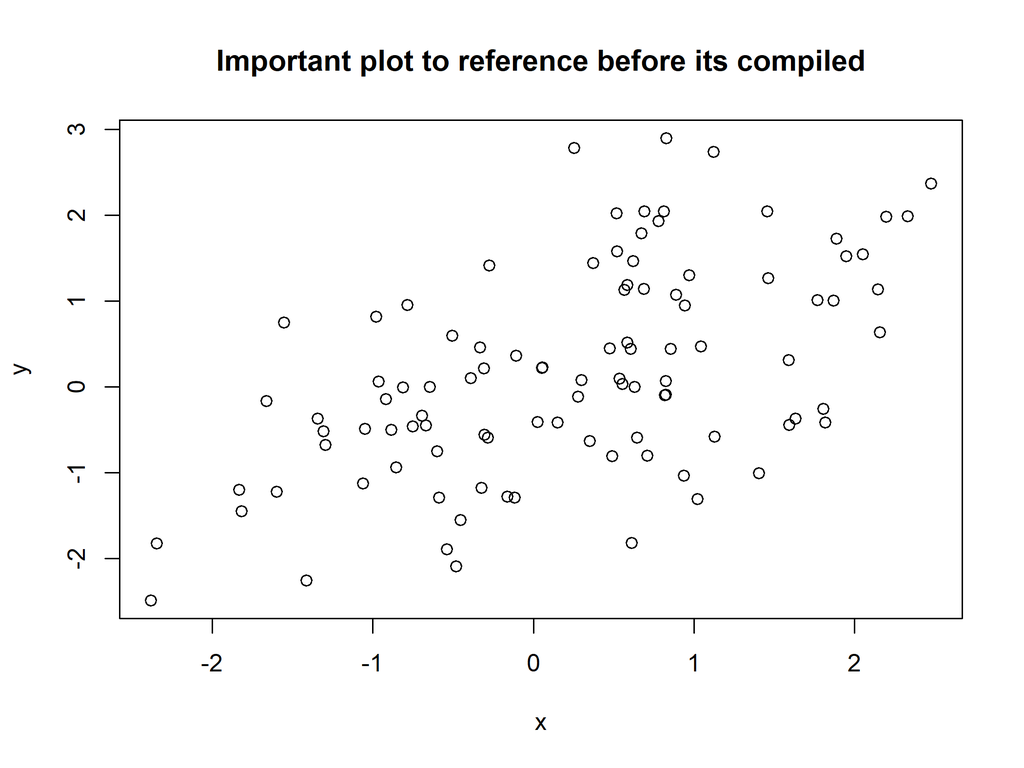

Executive graph for executive thoughts

## 1.2 Introduction

```
This is a text box if you like textboxes
```

Links can be given in this format (for html versions): [link](https://www.ncbi.nlm.nih.gov/pmc/articles/PMC6852019/)

Lorem ipsum dolor sit amet, consectetur adipiscing elit. Maecenas et justo non erat lobortis tincidunt. In et nunc sollicitudin, pellentesque neque sit amet, blandit mauris. Praesent nunc urna, mattis non risus eu, egestas bibendum nunc. Mauris et hendrerit purus. Morbi posuere nibh erat, vel dignissim nisl fermentum sed. Vivamus nisi tellus, placerat vitae accumsan nec, tincidunt ac leo. Phasellus sed dolor et massa placerat sodales. Nulla facilisi. Sed sed justo nec lacus egestas malesuada hendrerit quis ligula. Vestibulum in purus mattis, elementum quam sit amet, eleifend lorem. Nunc dictum ligula ante, sit amet auctor nisi aliquet non. Donec ullamcorper ultrices molestie.

Nunc sodales, massa ut vehicula auctor, augue felis faucibus urna, et semper libero tortor accumsan magna. Proin non tortor quis erat tempor fermentum et ut tortor. Praesent elementum tristique sapien a interdum. Aenean sit amet mi a sapien semper ullamcorper. Phasellus quis enim tempor, porttitor odio eu, faucibus libero. Nullam eu eros vitae eros dictum luctus. Mauris congue ante vel laoreet eleifend.

Nunc lobortis sapien ac eros venenatis commodo. Vestibulum a venenatis enim. Sed sit amet lectus gravida quam mollis porttitor eu ut elit. Etiam dolor massa, dignissim et facilisis vitae, congue ac sem. Proin sed sem condimentum, tincidunt sapien eget, accumsan dolor. Aenean varius mi ligula, nec scelerisque ligula dignissim ac. Cras ex magna, feugiat sed libero sed, vestibulum condimentum risus. Sed pretium maximus est, quis imperdiet purus consectetur vestibulum. Phasellus mattis sapien ante, convallis facilisis mi posuere quis. Maecenas id magna scelerisque, ultrices sem viverra, ornare lectus. Ut consectetur eleifend tortor sagittis venenatis. Cras quis lorem et odio tristique gravida. Sed sapien justo, euismod id ligula quis, fringilla egestas nulla. Aenean molestie felis ut aliquam scelerisque. Maecenas id ligula ultricies, tristique sem eu, eleifend est. Cras tempor feugiat nibh sit amet efficitur.

$~$

## 1.3 Deviations from the Protocol

Lorem ipsum dolor sit amet, consectetur adipiscing elit. Maecenas et justo non erat lobortis tincidunt. In et nunc sollicitudin, pellentesque neque sit amet, blandit mauris. Praesent nunc urna, mattis non risus eu, egestas bibendum nunc. Mauris et hendrerit purus. Morbi posuere nibh erat, vel dignissim nisl fermentum sed. Vivamus nisi tellus, placerat vitae accumsan nec, tincidunt ac leo. Phasellus sed dolor et massa placerat sodales. Nulla facilisi. Sed sed justo nec lacus egestas malesuada hendrerit quis ligula. Vestibulum in purus mattis, elementum quam sit amet, eleifend lorem. Nunc dictum ligula ante, sit amet auctor nisi aliquet non. Donec ullamcorper ultrices molestie.

Nunc lobortis sapien ac eros venenatis commodo. Vestibulum a venenatis enim. Sed sit amet lectus gravida quam mollis porttitor eu ut elit. Etiam dolor massa, dignissim et facilisis vitae, congue ac sem. Proin sed sem condimentum, tincidunt sapien eget, accumsan dolor. Aenean varius mi ligula, nec scelerisque ligula dignissim ac. Cras ex magna, feugiat sed libero sed, vestibulum condimentum risus. Sed pretium maximus est, quis imperdiet purus consectetur vestibulum. Phasellus mattis sapien ante, convallis facilisis mi posuere quis. Maecenas id magna scelerisque, ultrices sem viverra, ornare lectus. Ut consectetur eleifend tortor sagittis venenatis. Cras quis lorem et odio tristique gravida. Sed sapien justo, euismod id ligula quis, fringilla egestas nulla. Aenean molestie felis ut aliquam scelerisque. Maecenas id ligula ultricies, tristique sem eu, eleifend est. Cras tempor feugiat nibh sit amet efficitur.

## 1.4 Planned investigations

If you’re feeling cocky, spruce up your report with model descriptions in Latex, eg.:

$~$

$$log(Cool\ variable_{i,j}) = \alpha_0 +
\alpha_1\times Independent\ variable_1 +$$
$$\alpha_2\times Independent\ variable_{2,i,j} +
\alpha_3\times Sex_i + \\$$
$$\alpha_2\times Independent\ variable_{3,i,j} *
\alpha_{3,k} \times Treatment + \\$$
$$\delta_{0,i}+\delta_{1i}\times j+\epsilon_{i,j}$$

where,

- **i** is the subject number,
- **j** is the time point,
- **k** is the treatment,
- $\epsilon$ is the residual error, and
- $\delta$ represents the random effects.

$~$

## 1.5 Chapter title

### 1.5.1 Relevelling

*Lorem ipsum dolor sit amet, consectetur adipiscing elit. Maecenas et justo non erat lobortis tincidunt. In et nunc sollicitudin, pellentesque neque sit amet, blandit mauris. Praesent nunc urna, mattis non risus eu, egestas bibendum nunc. Mauris et hendrerit purus. Morbi posuere nibh erat, vel dignissim nisl fermentum sed. Vivamus nisi tellus, placerat vitae accumsan nec, tincidunt ac leo. Phasellus sed dolor et massa placerat sodales. Nulla facilisi. Sed sed justo nec lacus egestas malesuada hendrerit quis ligula. Vestibulum in purus mattis, elementum quam sit amet, eleifend lorem. Nunc dictum ligula ante, sit amet auctor nisi aliquet non. Donec ullamcorper ultrices molestie.*

Sorry, the below is a dull example of releveling:

```r
# This is an example of factor releveling snatched from
# https://www.tutorialspoint.com/r/r_factors.htm

data_f <- c("East", "West", "East", "North", "North", "East",
    "West", "West", "West", "East", "North")
# Create the factors
factor_data <- factor(data_f)
print(factor_data)
```

```
##  [1] East  West  East  North North East  West  West  West
## [10] East  North
## Levels: East North West
```

```r
# Apply the factor function with required order of the
# level.
new_order_data <- factor(factor_data, levels = c("East", "West",
    "North"))
print(new_order_data)
```

```
##  [1] East  West  East  North North East  West  West  West
## [10] East  North
## Levels: East West North
```

Nunc sodales, massa ut vehicula auctor, augue felis faucibus urna, et semper libero tortor accumsan magna. Proin non tortor quis erat tempor fermentum et ut tortor. Praesent elementum tristique sapien a interdum. Aenean sit amet mi a sapien semper ullamcorper. Phasellus quis enim tempor, porttitor odio eu, faucibus libero. Nullam eu eros vitae eros dictum luctus. Mauris congue ante vel laoreet eleifend.

### 1.5.2 Side-by-side log graphs

Lorem ipsum dolor sit amet, consectetur adipiscing elit. Maecenas et justo non erat lobortis tincidunt. In et nunc sollicitudin, pellentesque neque sit amet, blandit mauris. Praesent nunc urna, mattis non risus eu, egestas bibendum nunc. Mauris et hendrerit purus. Morbi posuere nibh erat, vel dignissim nisl fermentum sed. Vivamus nisi tellus, placerat vitae accumsan nec, tincidunt ac leo. Phasellus sed dolor et massa placerat sodales. Nulla facilisi. Sed sed justo nec lacus egestas malesuada hendrerit quis ligula. Vestibulum in purus mattis, elementum quam sit amet, eleifend lorem. Nunc dictum ligula ante, sit amet auctor nisi aliquet non. Donec ullamcorper ultrices molestie.

Nunc sodales, massa ut vehicula auctor, augue felis faucibus urna, et semper libero tortor accumsan magna. Proin non tortor quis erat tempor fermentum et ut tortor. Praesent elementum tristique sapien a interdum. Aenean sit amet mi a sapien semper ullamcorper. Phasellus quis enim tempor, porttitor odio eu, faucibus libero. Nullam eu eros vitae eros dictum luctus. Mauris congue ante vel laoreet eleifend.

Nunc lobortis sapien ac eros venenatis commodo. Vestibulum a venenatis enim. Sed sit amet lectus gravida quam mollis porttitor eu ut elit. Etiam dolor massa, dignissim et facilisis vitae, congue ac sem. Proin sed sem condimentum, tincidunt sapien eget, accumsan dolor. Aenean varius mi ligula, nec scelerisque ligula dignissim ac. Cras ex magna, feugiat sed libero sed, vestibulum condimentum risus. Sed pretium maximus est, quis imperdiet purus consectetur vestibulum. Phasellus mattis sapien ante, convallis facilisis mi posuere quis. Maecenas id magna scelerisque, ultrices sem viverra, ornare lectus. Ut consectetur eleifend tortor sagittis venenatis. Cras quis lorem et odio tristique gravida. Sed sapien justo, euismod id ligula quis, fringilla egestas nulla. Aenean molestie felis ut aliquam scelerisque. Maecenas id ligula ultricies, tristique sem eu, eleifend est. Cras tempor feugiat nibh sit amet efficitur.

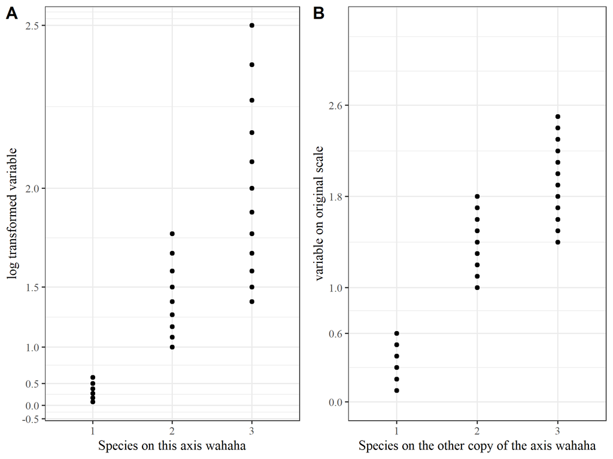

Title of the plot above

### 1.5.4 A tbl_summary example

Lorem ipsum dolor sit amet, consectetur adipiscing elit. Maecenas et justo non erat lobortis tincidunt. In et nunc sollicitudin, pellentesque neque sit amet, blandit mauris. Praesent nunc urna, mattis non risus eu, egestas bibendum nunc. Mauris et hendrerit purus. Morbi posuere nibh erat, vel dignissim nisl fermentum sed. Vivamus nisi tellus, placerat vitae accumsan nec, tincidunt ac leo. Phasellus sed dolor et massa placerat sodales. Nulla facilisi. Sed sed justo nec lacus egestas malesuada hendrerit quis ligula. Vestibulum in purus mattis, elementum quam sit amet, eleifend lorem. Nunc dictum ligula ante, sit amet auctor nisi aliquet non. Donec ullamcorper ultrices molestie.

Nunc sodales, massa ut vehicula auctor, augue felis faucibus urna, et semper libero tortor accumsan magna. Proin non tortor quis erat tempor fermentum et ut tortor. Praesent elementum tristique sapien a interdum. Aenean sit amet mi a sapien semper ullamcorper. Phasellus quis enim tempor, porttitor odio eu, faucibus libero. Nullam eu eros vitae eros dictum luctus. Mauris congue ante vel laoreet eleifend.

Nunc lobortis sapien ac eros venenatis commodo. Vestibulum a venenatis enim. Sed sit amet lectus gravida quam mollis porttitor eu ut elit. Etiam dolor massa, dignissim et facilisis vitae, congue ac sem. Proin sed sem condimentum, tincidunt sapien eget, accumsan dolor. Aenean varius mi ligula, nec scelerisque ligula dignissim ac. Cras ex magna, feugiat sed libero sed, vestibulum condimentum risus. Sed pretium maximus est, quis imperdiet purus consectetur vestibulum. Phasellus mattis sapien ante, convallis facilisis mi posuere quis. Maecenas id magna scelerisque, ultrices sem viverra, ornare lectus. Ut consectetur eleifend tortor sagittis venenatis. Cras quis lorem et odio tristique gravida. Sed sapien justo, euismod id ligula quis, fringilla egestas nulla. Aenean molestie felis ut aliquam scelerisque. Maecenas id ligula ultricies, tristique sem eu, eleifend est. Cras tempor feugiat nibh sit amet efficitur.

Plot without much thought or meaning

|  | **Setosa**, N = 50 | **Verginica**, N = 50 | **Versicolor**, N = 50 |
| --- | --- | --- | --- |
| Numeric representation of species |  |  |  |
| 1 | 50 (100%) | 0 (0%) | 0 (0%) |
| 2 | 0 (0%) | 0 (0%) | 50 (100%) |
| 3 | 0 (0%) | 50 (100%) | 0 (0%) |
| These are the width of the petals | 0.20 (0.20, 0.30) | 2.00 (1.80, 2.30) | 1.30 (1.20, 1.50) |
| These are the length of the petals | 1.50 (1.40, 1.58) | 5.55 (5.10, 5.88) | 4.35 (4.00, 4.60) |
| These are the width of the sepals | 3.40 (3.20, 3.68) | 3.00 (2.80, 3.18) | 2.80 (2.53, 3.00) |
| These are the length of the sepals | 5.00 (4.80, 5.20) | 6.50 (6.23, 6.90) | 5.90 (5.60, 6.30) |
| This is a date column to illustrate transformations | 2022-01-01 to 2022-02-19 | 2022-04-11 to 2022-05-30 | 2022-02-20 to 2022-04-10 |
| This is my new example variable, adding up the lengths | 3.70 (3.40, 3.90) | 4.95 (4.63, 5.38) | 4.20 (3.73, 4.40) |
| mock_ID | 8.0 (4.0, 11.8) | 11.0 (7.3, 16.0) | 13.5 (6.0, 16.8) |

$~$

Dis be the second table

| mpg | cyl | disp | hp | drat | wt | qsec | vs | am | gear | carb |
| --- | --- | --- | --- | --- | --- | --- | --- | --- | --- | --- |
| 21 | 6 | 160 | 110 | 3.9 | 2.62 | 16.46 | 0 | 1 | 4 | 4 |
| 21 | 6 | 160 | 110 | 3.9 | 2.875 | 17.02 | 0 | 1 | 4 | 4 |
| 22.8 | 4 | 108 | 93 | 3.85 | 2.32 | 18.61 | 1 | 1 | 4 | 1 |
| 21.4 | 6 | 258 | 110 | 3.08 | 3.215 | 19.44 | 1 | 0 | 3 | 1 |
| 18.7 | 8 | 360 | 175 | 3.15 | 3.44 | 17.02 | 0 | 0 | 3 | 2 |
| 18.1 | 6 | 225 | 105 | 2.76 | 3.46 | 20.22 | 1 | 0 | 3 | 1 |

### 1.5.5 A raincloud plot

Lorem ipsum dolor sit amet, consectetur adipiscing elit. Maecenas et justo non erat lobortis tincidunt. In et nunc sollicitudin, pellentesque neque sit amet, blandit mauris. Praesent nunc urna, mattis non risus eu, egestas bibendum nunc. Mauris et hendrerit purus. Morbi posuere nibh erat, vel dignissim nisl fermentum sed. Vivamus nisi tellus, placerat vitae accumsan nec, tincidunt ac leo. Phasellus sed dolor et massa placerat sodales. Nulla facilisi. Sed sed justo nec lacus egestas malesuada hendrerit quis ligula. Vestibulum in purus mattis, elementum quam sit amet, eleifend lorem. Nunc dictum ligula ante, sit amet auctor nisi aliquet non. Donec ullamcorper ultrices molestie.

Nunc sodales, massa ut vehicula auctor, augue felis faucibus urna, et semper libero tortor accumsan magna. Proin non tortor quis erat tempor fermentum et ut tortor. Praesent elementum tristique sapien a interdum. Aenean sit amet mi a sapien semper ullamcorper. Phasellus quis enim tempor, porttitor odio eu, faucibus libero. Nullam eu eros vitae eros dictum luctus. Mauris congue ante vel laoreet eleifend.

Nunc lobortis sapien ac eros venenatis commodo. Vestibulum a venenatis enim. Sed sit amet lectus gravida quam mollis porttitor eu ut elit. Etiam dolor massa, dignissim et facilisis vitae, congue ac sem. Proin sed sem condimentum, tincidunt sapien eget, accumsan dolor. Aenean varius mi ligula, nec scelerisque ligula dignissim ac. Cras ex magna, feugiat sed libero sed, vestibulum condimentum risus. Sed pretium maximus est, quis imperdiet purus consectetur vestibulum. Phasellus mattis sapien ante, convallis facilisis mi posuere quis. Maecenas id magna scelerisque, ultrices sem viverra, ornare lectus. Ut consectetur eleifend tortor sagittis venenatis. Cras quis lorem et odio tristique gravida. Sed sapien justo, euismod id ligula quis, fringilla egestas nulla. Aenean molestie felis ut aliquam scelerisque. Maecenas id ligula ultricies, tristique sem eu, eleifend est. Cras tempor feugiat nibh sit amet efficitur.

$~$

[figure not shown]

Raincloud plot(!)

$~$

$~$

Lorem ipsum dolor sit amet, consectetur adipiscing elit. Maecenas et justo non erat lobortis tincidunt. In et nunc sollicitudin, pellentesque neque sit amet, blandit mauris. Praesent nunc urna, mattis non risus eu, egestas bibendum nunc. Mauris et hendrerit purus. Morbi posuere nibh erat, vel dignissim nisl fermentum sed. Vivamus nisi tellus, placerat vitae accumsan nec, tincidunt ac leo. Phasellus sed dolor et massa placerat sodales. Nulla facilisi. Sed sed justo nec lacus egestas malesuada hendrerit quis ligula. Vestibulum in purus mattis, elementum quam sit amet, eleifend lorem. Nunc dictum ligula ante, sit amet auctor nisi aliquet non. Donec ullamcorper ultrices molestie.

Nunc sodales, massa ut vehicula auctor, augue felis faucibus urna, et semper libero tortor accumsan magna. Proin non tortor quis erat tempor fermentum et ut tortor. Praesent elementum tristique sapien a interdum. Aenean sit amet mi a sapien semper ullamcorper. Phasellus quis enim tempor, porttitor odio eu, faucibus libero. Nullam eu eros vitae eros dictum luctus. Mauris congue ante vel laoreet eleifend.

Nunc lobortis sapien ac eros venenatis commodo. Vestibulum a venenatis enim. Sed sit amet lectus gravida quam mollis porttitor eu ut elit. Etiam dolor massa, dignissim et facilisis vitae, congue ac sem. Proin sed sem condimentum, tincidunt sapien eget, accumsan dolor. Aenean varius mi ligula, nec scelerisque ligula dignissim ac. Cras ex magna, feugiat sed libero sed, vestibulum condimentum risus. Sed pretium maximus est, quis imperdiet purus consectetur vestibulum. Phasellus mattis sapien ante, convallis facilisis mi posuere quis. Maecenas id magna scelerisque, ultrices sem viverra, ornare lectus. Ut consectetur eleifend tortor sagittis venenatis. Cras quis lorem et odio tristique gravida. Sed sapien justo, euismod id ligula quis, fringilla egestas nulla. Aenean molestie felis ut aliquam scelerisque. Maecenas id ligula ultricies, tristique sem eu, eleifend est. Cras tempor feugiat nibh sit amet efficitur.

[figure not shown]

lmer predictions with bootstrap and labelled facets

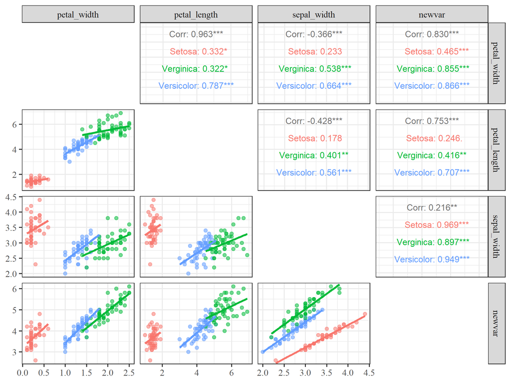

Especially Cool ‘pairs’ plot

[figure not shown]

# 2 Notes

The MD5 checksum of the database used:

```
## C:/OneDrive_DKM/-/Dinamikus Kiválóság Menedzsment - General/Stats_R/R/MartysCookbook/inst/extdata/Iris.xls
##                                                                         "1ed4b9d5418675e017479de339aff352"
```

Other information regarding the compilation of this document:

Analyses were conducted using the R Statistical language (version 4.3.0; R Core Team, 2023) on Windows 10 x64 (build 19045), using the packages rmarkdown (version 2.22; Allaire J et al., 2023), lme4 (version 1.1.33; Bates D et al., 2015), Matrix (version 1.5.4.1; Bates D et al., 2023), effects (version 4.2.2; Fox J, Weisberg S, 2019), carData (version 3.0.5; Fox J et al., 2022), lubridate (version 1.9.2; Grolemund G, Wickham H, 2011), DHARMa (version 0.4.6; Hartig F, 2022), huxtable (version 5.5.2; Hugh-Jones D, 2022), labelled (version 2.11.0; Larmarange J, 2023), emmeans (version 1.8.6; Lenth R, 2023), nlme (version 3.1.162; Pinheiro J et al., 2023), gtsummary (version 1.7.1; Sjoberg D et al., 2021), ggplot2 (version 3.4.2; Wickham H, 2016), readxl (version 1.4.2; Wickham H, Bryan J, 2023), roxygen2 (version 7.2.3; Wickham H et al., 2022), dplyr (version 1.1.2; Wickham H et al., 2023), knitr (version 1.43; Xie Y, 2023), pagedown (version 0.20; Xie Y et al., 2022) and kableExtra (version 1.3.4; Zhu H, 2021).

## 2.1 References

- Allaire J, Xie Y, Dervieux C, McPherson J, Luraschi J, Ushey K, Atkins A, Wickham H, Cheng J, Chang W, Iannone R (2023). *rmarkdown: Dynamic Documents for R*. R package version 2.22, https://github.com/rstudio/rmarkdown.
- Bates D, Mächler M, Bolker B, Walker S (2015). “Fitting Linear Mixed-Effects Models Using lme4.” *Journal of Statistical Software*, *67*(1), 1-48. .
- Bates D, Maechler M, Jagan M (2023). *Matrix: Sparse and Dense Matrix Classes and Methods*. R package version 1.5-4.1, https://CRAN.R-project.org/package=Matrix.
- Fox J, Weisberg S (2019). *An R Companion to Applied Regression*, 3rd edition. Sage, Thousand Oaks CA. https://socialsciences.mcmaster.ca/jfox/Books/Companion/index.html.
- Fox J, Weisberg S, Price B (2022). *carData: Companion to Applied Regression Data Sets*. R package version 3.0-5, https://CRAN.R-project.org/package=carData.
- Grolemund G, Wickham H (2011). “Dates and Times Made Easy with lubridate.” *Journal of Statistical Software*, *40*(3), 1-25. https://www.jstatsoft.org/v40/i03/.
- Hartig F (2022). *DHARMa: Residual Diagnostics for Hierarchical (Multi-Level / Mixed) Regression Models*. R package version 0.4.6, https://CRAN.R-project.org/package=DHARMa.
- Hugh-Jones D (2022). *huxtable: Easily Create and Style Tables for LaTeX, HTML and Other Formats*. R package version 5.5.2, https://CRAN.R-project.org/package=huxtable.
- Larmarange J (2023). *labelled: Manipulating Labelled Data*. R package version 2.11.0, https://CRAN.R-project.org/package=labelled.
- Lenth R (2023). *emmeans: Estimated Marginal Means, aka Least-Squares Means*. R package version 1.8.6, https://CRAN.R-project.org/package=emmeans.
- Pinheiro J, Bates D, R Core Team (2023). *nlme: Linear and Nonlinear Mixed Effects Models*. R package version 3.1-162, https://CRAN.R-project.org/package=nlme.
- R Core Team (2023). *R: A Language and Environment for Statistical Computing*. R Foundation for Statistical Computing, Vienna, Austria. https://www.R-project.org/.
- Sjoberg D, Whiting K, Curry M, Lavery J, Larmarange J (2021). “Reproducible Summary Tables with the gtsummary Package.” *The R Journal*, *13*, 570-580. , https://doi.org/10.32614/RJ-2021-053.
- Wickham H (2016). *ggplot2: Elegant Graphics for Data Analysis*. Springer-Verlag New York. ISBN 978-3-319-24277-4, https://ggplot2.tidyverse.org.
- Wickham H, Bryan J (2023). *readxl: Read Excel Files*. R package version 1.4.2, https://CRAN.R-project.org/package=readxl.
- Wickham H, Danenberg P, Csárdi G, Eugster M (2022). *roxygen2: In-Line Documentation for R*. R package version 7.2.3, https://CRAN.R-project.org/package=roxygen2.
- Wickham H, François R, Henry L, Müller K, Vaughan D (2023). *dplyr: A Grammar of Data Manipulation*. R package version 1.1.2, https://CRAN.R-project.org/package=dplyr.
- Xie Y (2023). *knitr: A General-Purpose Package for Dynamic Report Generation in R*. R package version 1.43, https://yihui.org/knitr/.
- Xie Y, Lesur R, Thorne B, Tan X (2022). *pagedown: Paginate the HTML Output of R Markdown with CSS for Print*. R package version 0.20, https://CRAN.R-project.org/package=pagedown.
- Zhu H (2021). *kableExtra: Construct Complex Table with ‘kable’ and Pipe Syntax*. R package version 1.3.4, https://CRAN.R-project.org/package=kableExtra.

This document was compiled at:

```
[1] "2023-06-12 11:49:12 CEST"
```

# 3 Appendix

This is how put all your code into an appendix.

```r
# https://dotcms.com/docs/latest/markdown-syntax
# https://yihui.org/knitr/options/
# https://zbib.org/
# https://www.r-bloggers.com/2019/09/first-world-problems-very-long-rmarkdown-documents/


# # For citations insert this into the yaml header (without spaces)
# # And make a book.bib file to the location of the mother .rmd
# bibliography: book.bib
# biblio-style: apalike
# link-citations: yes

source(here::here("inst","functions","load_stuff.r"))

knitr::opts_chunk$set(
    echo = FALSE,                           # Ne mutassa a kódokat
    cached = FALSE,                 ###!!!  # Ne cache-eljen
    warning = FALSE,                        # Ne írja ki a warningokat
    message = FALSE,
    fig.align = 'center',                   # Ábra középre rendezése
    out.width = '90%',                      # Ábra szélessége, alter.: #fig.fullwidth = TRUE,
    fig.asp = .75,                          # Ábra Hossz/szélesség
    tidy.opts = list(width.cutoff = 60),    # legyenek 60 karakter szélességűre tördelve
    tidy = "styler",                        # legyenek clean codingra megformázva
    dev = 'png',#'tiff',                            # PNG legyen az alapértelmezett képformátum
    compression = 'lzw',
    dpi = 300,                              # a PNG képek elég jó minőségűek legyenek
    fig.pos = 'H'                           # nem próbálja az ábrákat az oldal tetejére tenni
  )


graphics_path <- "../inst/figure/"            # a máshonnan származó ábrák elérési útja
graphics_output_path <- "cookbook_files/figure-latex/" # az itt generált ábrák elérési útja

options(scipen = 1) # Require 5 instead of 4 for scientific notation (eg. for p-values)
options(digits = 3) # default no. of digits (!)
options(encoding = "UTF-8")

plot(x,y)

save.image( file = here::here("inst","states", "before_chap1.Rdata"))

valtozok <- c("cyl", "gear", "carb")
out <- NULL

for (i in 1:length(valtozok)) {
  out <- c(out, paste0("\n### ", valtozok[i], "\n")) # Defining "title"
  params <- list(x              = valtozok[i],
                 top_level      = 4,
                 figname_prefix = valtozok[i])
  out <- c(out,
           knitr::knit_child(here::here("inst",'cyclic_chap2.Rmd'),
                             quiet = T))
}
out <- paste(out, collapse = "\n")

set.seed(12345)

x <- rnorm(100)
y <- 0.5 * x + rnorm(100)

plot(x,y, main = "Important plot to reference before its compiled")

tools::md5sum(here::here("inst","extdata","Iris.xls"))
knitr::opts_chunk$set(comment = NA)
sessionInfo() %>% report::report() %>% cat()

Sys.time()
save.image(file = here::here("inst","states","cookbook_out.Rdata"))



source(here::here("inst","functions","load_stuff.r"))
load( file = here::here("inst","states", "before_chap1.Rdata"))

graphics_output_path <- "cookbook_files/figure-latex/" # az itt generált ábrák elérési útja

# This is an example of factor releveling snatched from
# https://www.tutorialspoint.com/r/r_factors.htm

data_f <- c("East","West","East","North","North","East","West",
   "West","West","East","North")
# Create the factors
factor_data <- factor(data_f)
print(factor_data)

# Apply the factor function with required order of the level.
new_order_data <- factor(factor_data,levels = c("East","West","North"))
print(new_order_data)



# First subplot
fig_1a <-
data %>%
  ggplot( aes( x = species_no,
               y = petal_width)) +
  # Theme
  theme_default_ggplot +
  # Layers
  geom_point() +
  # axis wrangling
  scale_y_continuous(
    # setting up a custom log transform ( the pre-defined results in error somehow...)
    trans = scales::trans_new("expmar", exp,
            function(x){
                #print(paste("isq",x))  #debug statement
                x <-ifelse(x<0, 0, x)
                log(x)
              })
  ) +
  # description(s)
  labs( x = "Species on this axis wahaha",
        y = "log transformed variable")


# Second subplot
fig_1b <-
data %>%
  ggplot( aes( x = species_no,
               y = petal_width)) +
  # Theme
  theme_default_ggplot +
  theme( legend.position="bottom") + # custom legend position if needed
  # Layers
  geom_point() +
  # axis wrangling
  scale_y_continuous(
    limits = c( 0,3.3),
    breaks = c( 0, .6, 1, 1.8, 2.6)
  ) +
  # description(s)
  labs( x = "Species on the other copy of the axis wahaha",
        y = "variable on original scale")

# Demonstrating arranging plots
fig_1comp <-
  ggpubr::ggarrange(fig_1a, fig_1b,
          #labels = c("", ""), # if you'd like to omit the labels
          labels = "AUTO",
          ncol = 2, nrow = 1)

# calling the plot
(fig_1comp)


data_local <- data.frame( x = rnorm(100)) %>%
                mutate(y = x * 0.5 + rnorm(100))

data_local %>%
  ggplot( aes(x=x,y=y)) +
    theme_default_ggplot +
    geom_point()

hist(data_local$x)



tbl_summary( data, by = species_char) %>%
  martys_table_style(caption. =
                       "Plot without much thought or meaning") %>%
  # You can 'overwrite' setting which don't conflict your defaults
  set_font_size(7) %>%
  ###### row_spec(0, bold = T, font_size = 7)# %>% # Dis crashes the whole thing
   set_width(.4)


head(mtcars) %>%
  martys_table_style(caption. = "Dis be the second table")



# Calling the plot
plot. <-
  data %>%
    ggplot( aes(x = species_char, y = sepal_width,
                color = species_char, fill = species_char)) +
    theme_default_ggplot +
    # half smoothed density
    ggdist::stat_halfeye(
      ## bandwidth
      adjust = 0.6,
      justification = -.2,
      .width = 0,
      width = .25
    ) +
    # Boxplot
    geom_boxplot( width = .08,
                  # remove outliers from boxplot
                  outlier.color = NA,
                  alpha = .5) +
    # Dotplot
    ggdist::stat_dots(
      side = "left",
      dotsize = .1,
      justification = 1.12,
      binwidth = .125
    ) +
    labs(
      # coord_flip doesn't affect this ;)
      x = "Species",
      y = "Width of sepals (mm)",
      # Including latex, see https://cran.r-project.org/web/packages/latex2exp/vignettes/using-latex2exp.html
      caption = latex2exp::TeX(r"($   \alpha^{5-i_j}\ is\ a\ nifty\ string   $)"),
      title = "Its not better to set titles in ggplot2..."
      ) +
    scale_y_continuous(
      breaks = c(0,1,2,3,4,5),
      limits = c(0,5)) +
    coord_flip()
```